# Homework 4

James Young

References : Stack Exchange

Collaborators : None

Libraries used in this report are included below.

Please do the following problems from the text book R Handbook and stated.

1. The data from contains the velocities of 82 galaxies from six well-separated conic sections of space (Postman et al., 1986, Roeder, 1990). The data are intended to shed light on whether or not the observable universe contains superclusters of galaxies surrounded by large voids. The evidence for the existence of superclusters would be the multimodality of the distribution of velocities.(8.1 Handbook)

   a.) Construct histograms using the following functions:

   ```
   -hist() and ggplot()+geom_histogram()

   -truehist() and ggplot+geom_histogram() (pay attention to the y-axis!)

   -qplot()
   ```

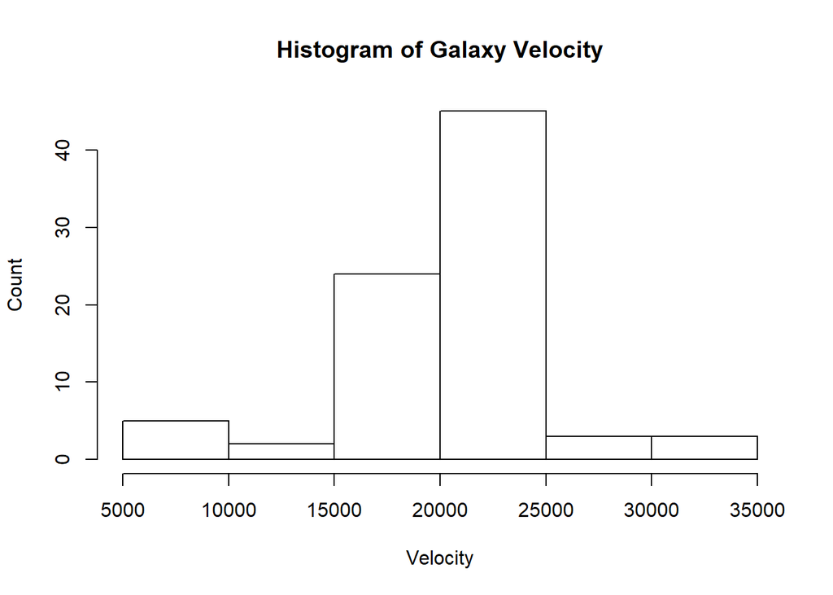

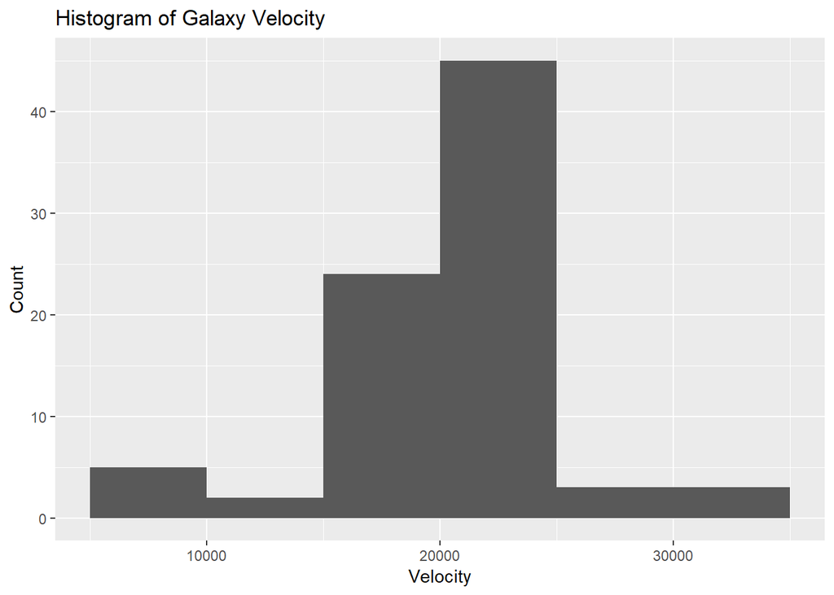

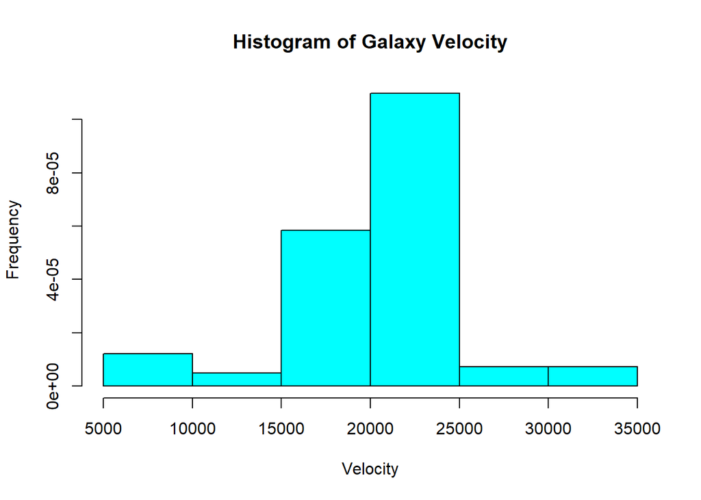

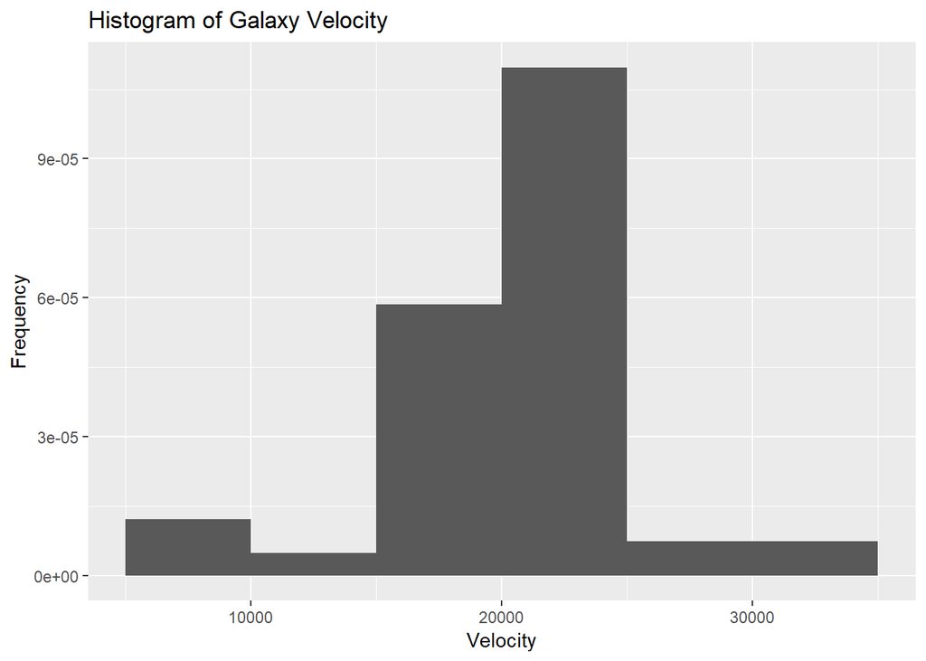

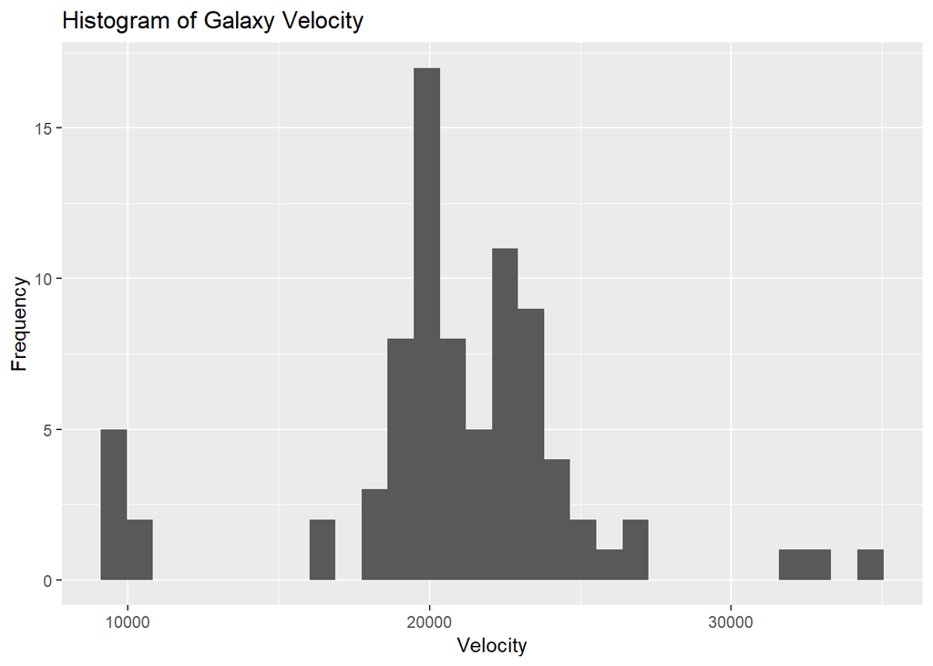

```
Comment on the shape and distribution of the variable based on the three plots. (Hint: Also play around with binning)
```

# My Thoughts: Both histograms and “truehist” histograms had similar shapes. The histograms for the part a) used count in the y-axis while the histograms for part b) used frequency. It looks like the frequency in part b) does not add to 1, however.Lastly, qplot (also using frequency on y-axis) looks different from the rest of the histograms as there are gaps between velocity data.

```
b.) Create a new variable \textit{loggalaxies} = $\log$(galaxies). Construct histograms using the functions in part a.) and comment on the shape and differences.
```

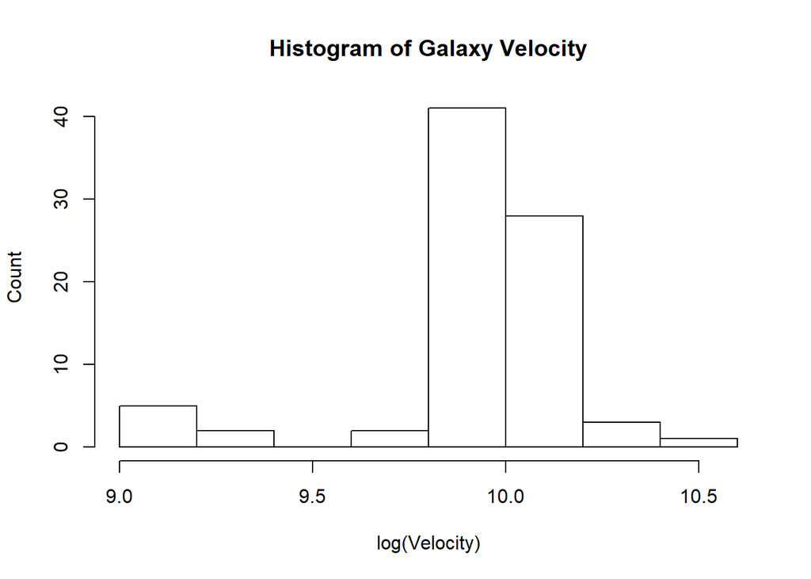

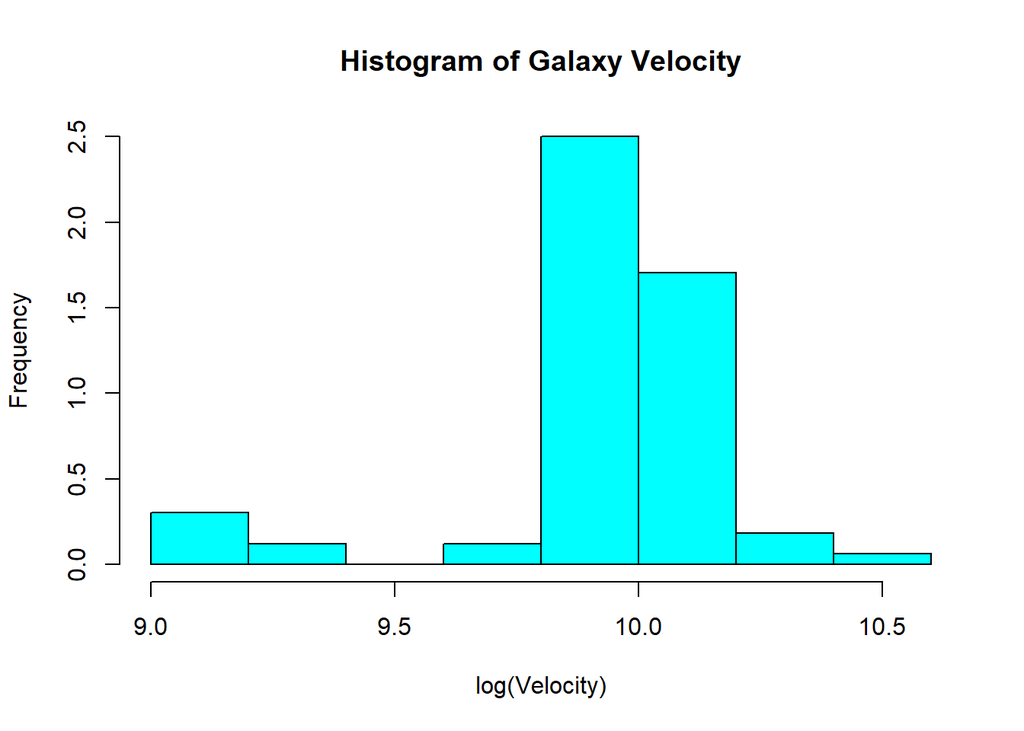

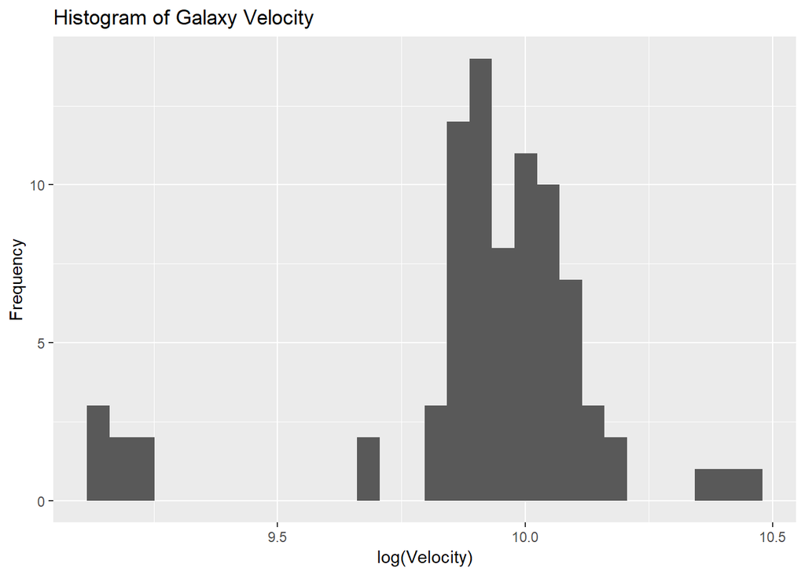

# My Thoughts: The histogram looks similar to truehist again (now using log velocity). We see a frequency in truehist that doesn’t look like it will add up to 1, which is confusing. Looking online some people suggested it may be a probability density issue if the variance is less than 1. And we also see qplot has narrower bins than the other two histograms. Qplot, also with frequency as the y-axis, again shows separation between velocities.

[output not shown]

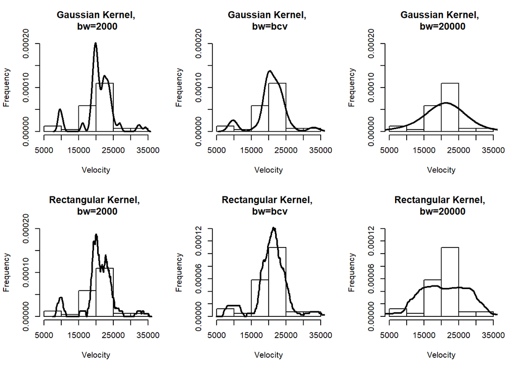

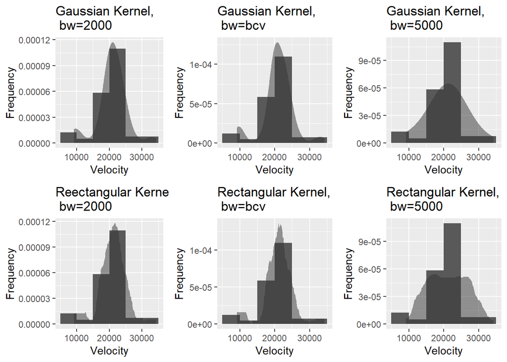

```
d.) What is your conclusion about the possible existence of superclusterd of galaxies? How many superclusters (1,2, 3, ... )?
```

# My Thoughts: The histograms from the first part of the question make me think there is either 2 or 3 superclusters, one in the middle and two on the edge. The histograms with kernels give different indications depending on the width used. Undersmoothing caused the appearance of two peaks in the middle which in addition to the two at the edges of velocity may imply 4 superclusters. The “appropriate”" smoothing using biased cross-validation method shows 3 peaks and the over smoothing shows 1 broad peak or possibly 2 weakly defined peaks. Note, I did change the badwidth between base r with histogram and ggplot to try to achieve the same aesthetic. My last observation is that gaussian is much smoother than rectangular kernels.

```
e.) How many clusters did it find? Did it match with your answer from (d) above? Report parameter estimates and BIC of the best model.
```

```
## ----------------------------------------------------
## Gaussian finite mixture model fitted by EM algorithm
## ----------------------------------------------------
##
## Mclust V (univariate, unequal variance) model with 4 components:
##
##  log-likelihood  n df       BIC       ICL
##        -765.694 82 11 -1579.862 -1598.907
##
## Clustering table:
##  1  2  3  4
##  7 35 32  8
##
## Mixing probabilities:
##          1          2          3          4
## 0.08440635 0.38660329 0.37116156 0.15782880
##
## Means:
##         1         2         3         4
##  9707.492 19804.259 22879.486 24459.536
##
## Variances:
##          1          2          3          4
##   177296.7   436160.9  1261611.3 34437115.3
```

```
## Bayesian Information Criterion (BIC):
##           E         V
## 1 -1622.361 -1622.361
## 2 -1631.243 -1595.403
## 3 -1584.016 -1592.299
## 4 -1592.828 -1579.862
## 5 -1592.299 -1593.277
## 6 -1601.228 -1604.069
## 7 -1588.610 -1611.538
## 8 -1597.427 -1625.804
## 9 -1600.709 -1633.494
##
## Top 3 models based on the BIC criterion:
##       V,4       E,3       E,7
## -1579.862 -1584.016 -1588.610
```

# My Thoughts: 4 clusters were found which is more than what I expected (3). The qplot from the beginning separated out the clusters fairly well if we judge it based on agreement with clustering.What I determined to by “under-smoothing” showed 4 peaks which would be in agreement with the clustering here.The best clustering based on BIC was model 4 with BIC = -1579.862 and means of clusters at 9707.492 19804.259 22879.486 24459.536.

Lets look at the clustering model with the best BIC score. We see 3 peaks but the clustering derived 4 clusters.

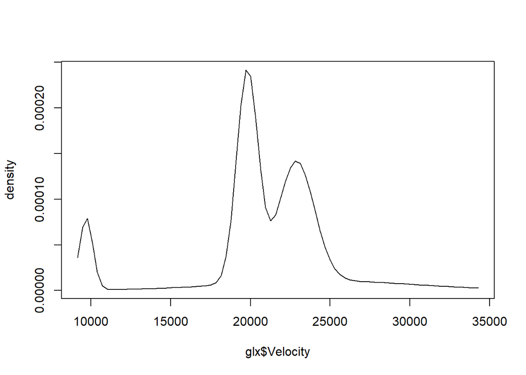

2. The data from gives the birth and death rates for 69 countries (from Hartigan, 1975). (8.2 Handbook)

   a.) Produce a scatterplot of the data and overlay a contour plot of the estimated bivariate density.

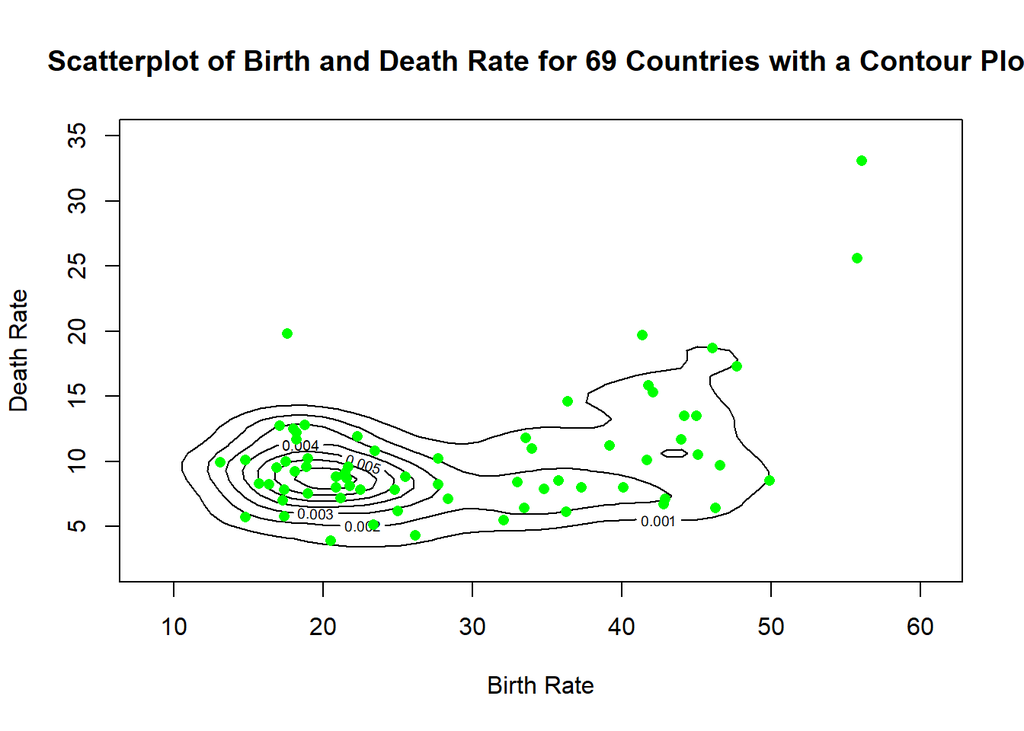

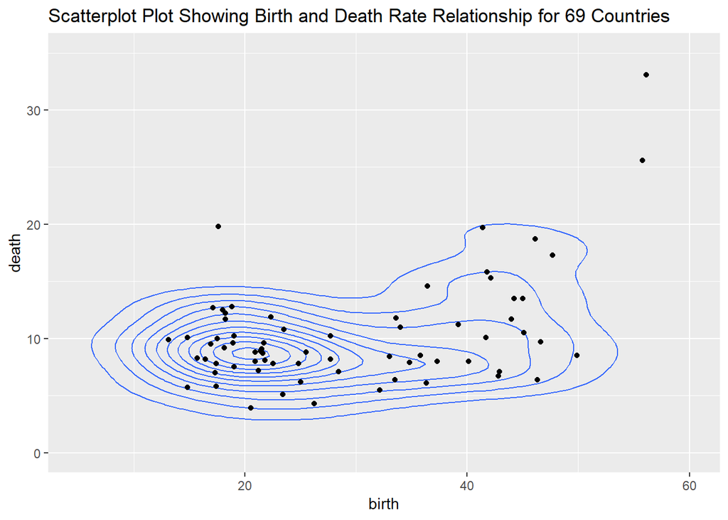

   b.) Does the plot give you any interesting insights into the possible structure of the data?